# data-carpentry-script

# Starting with data

Download metadata file from GitHub:

```r
download.file("https://raw.githubusercontent.com/datacarpentry/R-genomics/gh-pages/data/Ecoli_metadata.csv", "data/Ecoli_metadata.csv")
```

# Using data in data frames

Next we want to learn how to process data that we have stored in a dataframe.

Important things to learn:

- Extract values from a vector
- Extract rows and columns from a dataframe

## Extracting values with indexing and sequences

Columns in a dataframe are vectors. Hence, we start with vectors:

Make a simple vector:

```r
ten_letters <- c("a","b","c","d","e","f","g","h","i","j")
```

We can extract a value by using the square brackets with an index:

```r
ten_letters[2]
```

```
## [1] "b"
```

To extract multiple values at once you can use:

- a vector of indices
- a sequence of indices. A regular sequence can be written by using the colon operator.

```r
ten_letters[c(1,7)]
```

```
## [1] "a" "g"
```

```r
ten_letters[3:6]
```

```
## [1] "c" "d" "e" "f"
```

```r
ten_letters[10:1]
```

```
##  [1] "j" "i" "h" "g" "f" "e" "d" "c" "b" "a"
```

```r
ten_letters[c(2, 8:10)]
```

```
## [1] "b" "h" "i" "j"
```

In case you want to extract every second value, you can create a sequence of indices using the function seq().

```r
seq(1, 10, by = 2)
```

```
## [1] 1 3 5 7 9
```

```r
seq(20, 4, by = -3)
```

```
## [1] 20 17 14 11  8  5
```

### Exercise:

Extract every second value from the vector ten_letters:

```r
ten_letters[seq(1, 10, by = 2)]
```

```
## [1] "a" "c" "e" "g" "i"
```

## Extracting values, rows, and colums from dataframes

First let us load the Ecoli metadata again:

```r
metadata <- read.csv('data/Ecoli_metadata.csv')
```

Since dataframes are 2 dimensional (rows and columns), we need to provide indices for both dimensions. Hence the format is: dataframe[row_index, column_index]

```r
metadata[1, 2]   # 1st element in the 2nd column
```

```
## [1] 0
```

```r
metadata[1, 6]   # 1st element in the 6th column
```

```
## [1]
## 30 Levels:  SRR097977 SRR098026 SRR098027 SRR098028 SRR098029 ... SRR098289
```

```r
metadata[1:3, 7] # First three elements in the 7th column
```

```
## [1] 4.62 4.63 4.60
```

```r
metadata[3, ]    # 3rd element for all columns
```

```
##   sample generation   clade strain     cit       run genome_size
## 3 ZDB409       5000 unknown REL606 unknown SRR098281         4.6
```

```r
metadata[, 7]    # Entire 7th column
```

```
##  [1] 4.62 4.63 4.60 4.59 4.66 4.63 4.62 4.61 4.65 4.59 4.61 4.62 4.62 4.63 4.74
## [16] 4.61 4.77 4.63 4.79 4.59 4.80 4.76 4.60 4.75 4.74 4.61 4.79 4.62 4.78 4.62
```

Since columns can move in your dataset, you can also use the name of the column instead of the index:

```r
metadata[ , "strain"]
```

```
##  [1] REL606 REL606 REL606 REL606 REL606 REL606 REL606 REL606 REL606 REL606
## [11] REL606 REL606 REL606 REL606 REL606 REL606 REL606 REL606 REL606 REL606
## [21] REL606 REL606 REL606 REL606 REL606 REL606 REL606 REL606 REL606 REL606
## Levels: REL606
```

```r
metadata[ , c("strain", "clade")]
```

```
##    strain   clade
## 1  REL606    <NA>
## 2  REL606 unknown
## 3  REL606 unknown
## 4  REL606      UC
## 5  REL606      UC
## 6  REL606 (C1,C2)
## 7  REL606 (C1,C2)
## 8  REL606 (C1,C2)
## 9  REL606      C1
## 10 REL606      C3
## 11 REL606      C1
## 12 REL606      C2
## 13 REL606      C1
## 14 REL606      C2
```

[output cut: 16 more lines]

```r
metadata[4:7, c("strain", "clade")]
```

```
##   strain   clade
## 4 REL606      UC
## 5 REL606      UC
## 6 REL606 (C1,C2)
## 7 REL606 (C1,C2)
```

To extract a specific column you can also use the dollar sign operator:

dataframe$column_name

```r
metadata$strain
```

```
##  [1] REL606 REL606 REL606 REL606 REL606 REL606 REL606 REL606 REL606 REL606
## [11] REL606 REL606 REL606 REL606 REL606 REL606 REL606 REL606 REL606 REL606
## [21] REL606 REL606 REL606 REL606 REL606 REL606 REL606 REL606 REL606 REL606
## Levels: REL606
```

```r
metadata$strain[2]
```

```
## [1] REL606
## Levels: REL606
```

# Data manipulation using dplyr

To make data manipulation easier, people have create the package dplyr.

A package is basically a collection of functions.

After the package was installed, you need to load the package.

Packages always need to be loaded at the beginning of a new R session:

```r
library("dplyr")          ## load
```

Dplyr is part of a collection of packages that can help you with data manipulation, visualization and analysis. Look at the following website:

https://www.tidyverse.org/

## Selecting columns and filtering rows

How to use the following dplyr functions:

- select()
- filter()
- Using pipes %>%
- mutate()
- group_by()
- summarize()

### Select()

We can use the function select() to choose columns in a dataframe.

Usage: select(.data, ...)

```r
select(metadata, sample, clade, cit, genome_size)
```

```
##      sample   clade     cit genome_size
## 1    REL606    <NA> unknown        4.62
## 2  REL1166A unknown unknown        4.63
## 3    ZDB409 unknown unknown        4.60
## 4    ZDB429      UC unknown        4.59
## 5    ZDB446      UC unknown        4.66
## 6    ZDB458 (C1,C2) unknown        4.63
## 7   ZDB464* (C1,C2) unknown        4.62
## 8    ZDB467 (C1,C2) unknown        4.61
## 9    ZDB477      C1 unknown        4.65
## 10   ZDB483      C3 unknown        4.59
## 11    ZDB16      C1 unknown        4.61
## 12   ZDB357      C2 unknown        4.62
## 13  ZDB199*      C1   minus        4.62
## 14   ZDB200      C2   minus        4.63
```

[output cut: 16 more lines]

We can also un-select columns:

```r
select(metadata, -run, -genome_size)
```

```
##      sample generation   clade strain     cit
## 1    REL606          0    <NA> REL606 unknown
## 2  REL1166A       2000 unknown REL606 unknown
## 3    ZDB409       5000 unknown REL606 unknown
## 4    ZDB429      10000      UC REL606 unknown
## 5    ZDB446      15000      UC REL606 unknown
## 6    ZDB458      20000 (C1,C2) REL606 unknown
## 7   ZDB464*      20000 (C1,C2) REL606 unknown
## 8    ZDB467      20000 (C1,C2) REL606 unknown
## 9    ZDB477      25000      C1 REL606 unknown
## 10   ZDB483      25000      C3 REL606 unknown
## 11    ZDB16      30000      C1 REL606 unknown
## 12   ZDB357      30000      C2 REL606 unknown
## 13  ZDB199*      31500      C1 REL606   minus
## 14   ZDB200      31500      C2 REL606   minus
```

[output cut: 16 more lines]

### Filter()

To manipulate rows we can use the function filter():

```r
filter(metadata, cit == "plus") #filter for rows with samples that contain citrate using mutants
```

```
##     sample generation clade strain  cit       run genome_size
## 1   ZDB564      31500  Cit+ REL606 plus SRR098289        4.74
## 2   ZDB172      32000  Cit+ REL606 plus SRR098042        4.77
## 3   ZDB143      32500  Cit+ REL606 plus SRR098040        4.79
## 4   CZB152      33000  Cit+ REL606 plus SRR097977        4.80
## 5   CZB154      33000  Cit+ REL606 plus SRR098026        4.76
## 6    ZDB87      34000    C2 REL606 plus SRR098035        4.75
## 7    ZDB96      36000  Cit+ REL606 plus SRR098036        4.74
## 8   ZDB107      38000  Cit+ REL606 plus SRR098038        4.79
## 9 REL10979      40000  Cit+ REL606 plus SRR098029        4.78
```

```r
filter(metadata, cit != "plus") #exclude rows with samples that contain citrate using mutants
```

```
##      sample generation   clade strain     cit       run genome_size
## 1    REL606          0    <NA> REL606 unknown                  4.62
## 2  REL1166A       2000 unknown REL606 unknown SRR098028        4.63
## 3    ZDB409       5000 unknown REL606 unknown SRR098281        4.60
## 4    ZDB429      10000      UC REL606 unknown SRR098282        4.59
## 5    ZDB446      15000      UC REL606 unknown SRR098283        4.66
## 6    ZDB458      20000 (C1,C2) REL606 unknown SRR098284        4.63
## 7   ZDB464*      20000 (C1,C2) REL606 unknown SRR098285        4.62
## 8    ZDB467      20000 (C1,C2) REL606 unknown SRR098286        4.61
## 9    ZDB477      25000      C1 REL606 unknown SRR098287        4.65
## 10   ZDB483      25000      C3 REL606 unknown SRR098288        4.59
## 11    ZDB16      30000      C1 REL606 unknown SRR098031        4.61
## 12   ZDB357      30000      C2 REL606 unknown SRR098280        4.62
## 13  ZDB199*      31500      C1 REL606   minus SRR098044        4.62
## 14   ZDB200      31500      C2 REL606   minus SRR098279        4.63
## 15   ZDB30*      32000      C3 REL606   minus SRR098032        4.61
## 16   ZDB158      32500      C2 REL606   minus SRR098041        4.63
## 17   CZB199      33000      C1 REL606   minus SRR098027        4.59
## 18    ZDB83      34000    Cit+ REL606   minus SRR098034        4.60
## 19    ZDB99      36000      C1 REL606   minus SRR098037        4.61
## 20   ZDB111      38000      C2 REL606   minus SRR098039        4.62
## 21 REL10988      40000      C2 REL606   minus SRR098030        4.62
```

### Pipes

You can chain functions together by using the pipe operator (%>%). This operator comes from the package called magrittr, which was installed as part of the package dplyr.

```r
metadata %>%
  filter(cit == "plus") %>%
  select(sample, generation, clade)
```

```
##     sample generation clade
## 1   ZDB564      31500  Cit+
## 2   ZDB172      32000  Cit+
## 3   ZDB143      32500  Cit+
## 4   CZB152      33000  Cit+
## 5   CZB154      33000  Cit+
## 6    ZDB87      34000    C2
## 7    ZDB96      36000  Cit+
## 8   ZDB107      38000  Cit+
## 9 REL10979      40000  Cit+
```

Note that you don't need to include the data source in each function now.

You can assign the processed data to a new dataframe this way:

```r
meta_citplus <- metadata %>%
  filter(cit == "plus") %>%
  select(sample, generation, clade)

meta_citplus
```

```
##     sample generation clade
## 1   ZDB564      31500  Cit+
## 2   ZDB172      32000  Cit+
## 3   ZDB143      32500  Cit+
## 4   CZB152      33000  Cit+
## 5   CZB154      33000  Cit+
## 6    ZDB87      34000    C2
## 7    ZDB96      36000  Cit+
## 8   ZDB107      38000  Cit+
## 9 REL10979      40000  Cit+
```

#### Challenge

Using pipes, subset the data to include rows where the clade is ‘Cit+’. Retain columns sample, cit, and genome_size.

```r
metadata %>%
  filter(clade == "Cit+") %>%
  select(sample, cit, genome_size)
```

```
##     sample   cit genome_size
## 1   ZDB564  plus        4.74
## 2   ZDB172  plus        4.77
## 3   ZDB143  plus        4.79
## 4   CZB152  plus        4.80
## 5   CZB154  plus        4.76
## 6    ZDB83 minus        4.60
## 7    ZDB96  plus        4.74
## 8   ZDB107  plus        4.79
## 9 REL10979  plus        4.78
```

### Mutate()

Use the function mutate() when you want to calculate values from existing columns and store those in a new column:

```r
metadata %>%
  mutate(genome_bp = genome_size *1e6)
```

```
##      sample generation   clade strain     cit       run genome_size genome_bp
## 1    REL606          0    <NA> REL606 unknown                  4.62   4620000
## 2  REL1166A       2000 unknown REL606 unknown SRR098028        4.63   4630000
## 3    ZDB409       5000 unknown REL606 unknown SRR098281        4.60   4600000
## 4    ZDB429      10000      UC REL606 unknown SRR098282        4.59   4590000
## 5    ZDB446      15000      UC REL606 unknown SRR098283        4.66   4660000
## 6    ZDB458      20000 (C1,C2) REL606 unknown SRR098284        4.63   4630000
## 7   ZDB464*      20000 (C1,C2) REL606 unknown SRR098285        4.62   4620000
## 8    ZDB467      20000 (C1,C2) REL606 unknown SRR098286        4.61   4610000
## 9    ZDB477      25000      C1 REL606 unknown SRR098287        4.65   4650000
## 10   ZDB483      25000      C3 REL606 unknown SRR098288        4.59   4590000
## 11    ZDB16      30000      C1 REL606 unknown SRR098031        4.61   4610000
## 12   ZDB357      30000      C2 REL606 unknown SRR098280        4.62   4620000
## 13  ZDB199*      31500      C1 REL606   minus SRR098044        4.62   4620000
## 14   ZDB200      31500      C2 REL606   minus SRR098279        4.63   4630000
```

[output cut: 16 more lines]

You can add the function head() using the pipe operator to view the top rows:

```r
metadata %>%
  mutate(genome_bp = genome_size *1e6) %>%
  head
```

```
##     sample generation   clade strain     cit       run genome_size genome_bp
## 1   REL606          0    <NA> REL606 unknown                  4.62   4620000
## 2 REL1166A       2000 unknown REL606 unknown SRR098028        4.63   4630000
## 3   ZDB409       5000 unknown REL606 unknown SRR098281        4.60   4600000
## 4   ZDB429      10000      UC REL606 unknown SRR098282        4.59   4590000
## 5   ZDB446      15000      UC REL606 unknown SRR098283        4.66   4660000
## 6   ZDB458      20000 (C1,C2) REL606 unknown SRR098284        4.63   4630000
```

You can remove the row countaining NA in clade the following way:

```r
metadata %>%
  mutate(genome_bp = genome_size *1e6) %>%
  filter(!is.na(clade)) %>%
  head
```

```
##     sample generation   clade strain     cit       run genome_size genome_bp
## 1 REL1166A       2000 unknown REL606 unknown SRR098028        4.63   4630000
## 2   ZDB409       5000 unknown REL606 unknown SRR098281        4.60   4600000
## 3   ZDB429      10000      UC REL606 unknown SRR098282        4.59   4590000
## 4   ZDB446      15000      UC REL606 unknown SRR098283        4.66   4660000
## 5   ZDB458      20000 (C1,C2) REL606 unknown SRR098284        4.63   4630000
## 6  ZDB464*      20000 (C1,C2) REL606 unknown SRR098285        4.62   4620000
```

### group_by() and summarize()

Think about how you want to split your data to make a summary.

The group_by() function helps you to split your data.

The summarize() function helps you to create a summary of the groups:

```r
metadata %>%
  group_by(cit) %>%
  summarize(n())
```

```
## # A tibble: 3 x 2
##   cit     `n()`
##   <fct>   <int>
## 1 minus       9
## 2 plus        9
## 3 unknown    12
```

In the summarize() function we used the function n() to count the observations. But we can also use functions like mean(), median(), min(), and max() to create summaries.

Missing values such as NA will interfere with certain functions. Therefore, it is best to tell summarize functions to ignore NAs:

```r
metadata %>%
  group_by(cit) %>%
  summarize(mean_size = mean(genome_size, na.rm = TRUE))
```

```
## # A tibble: 3 x 2
##   cit     mean_size
##   <fct>       <dbl>
## 1 minus        4.61
## 2 plus         4.77
## 3 unknown      4.62
```

Group by multiple columns:

```r
metadata %>%
  group_by(cit, clade) %>%
  summarize(mean_size = mean(genome_size, na.rm = TRUE))
```

```
## # A tibble: 13 x 3
## # Groups:   cit [3]
##    cit     clade   mean_size
##    <fct>   <fct>       <dbl>
##  1 minus   C1           4.61
##  2 minus   C2           4.62
##  3 minus   C3           4.61
##  4 minus   Cit+         4.6
##  5 plus    C2           4.75
##  6 plus    Cit+         4.77
##  7 unknown (C1,C2)      4.62
##  8 unknown C1           4.63
##  9 unknown C2           4.62
## 10 unknown C3           4.59
## 11 unknown UC           4.62
## 12 unknown unknown      4.62
## 13 unknown <NA>         4.62
```

Remove the NA in clade:

```r
metadata %>%
  group_by(cit, clade) %>%
  summarize(mean_size = mean(genome_size, na.rm = TRUE)) %>%
  filter(!is.na(clade))
```

```
## # A tibble: 12 x 3
## # Groups:   cit [3]
##    cit     clade   mean_size
##    <fct>   <fct>       <dbl>
##  1 minus   C1           4.61
##  2 minus   C2           4.62
##  3 minus   C3           4.61
##  4 minus   Cit+         4.6
##  5 plus    C2           4.75
##  6 plus    Cit+         4.77
##  7 unknown (C1,C2)      4.62
##  8 unknown C1           4.63
##  9 unknown C2           4.62
## 10 unknown C3           4.59
## 11 unknown UC           4.62
## 12 unknown unknown      4.62
```

Summarize multiple variables:

```r
metadata %>%
  group_by(cit, clade) %>%
  summarize(mean_size = mean(genome_size, na.rm = TRUE),
            min_generation = min(generation))
```

```
## # A tibble: 13 x 4
## # Groups:   cit [3]
##    cit     clade   mean_size min_generation
##    <fct>   <fct>       <dbl>          <int>
##  1 minus   C1           4.61          31500
##  2 minus   C2           4.62          31500
##  3 minus   C3           4.61          32000
##  4 minus   Cit+         4.6           34000
##  5 plus    C2           4.75          34000
##  6 plus    Cit+         4.77          31500
##  7 unknown (C1,C2)      4.62          20000
##  8 unknown C1           4.63          25000
##  9 unknown C2           4.62          30000
## 10 unknown C3           4.59          25000
## 11 unknown UC           4.62          10000
## 12 unknown unknown      4.62           2000
## 13 unknown <NA>         4.62              0
```

You can find a dplyr cheatsheet here: https://rstudio.com/wp-content/uploads/2015/02/data-wrangling-cheatsheet.pdf

# Data Visualization

To visualize the data we can use:

- R base plots
- ggplot that is part of the tidyverse

## R base plots:

### Scatterplot

Use the function plot() to create scatterplots:

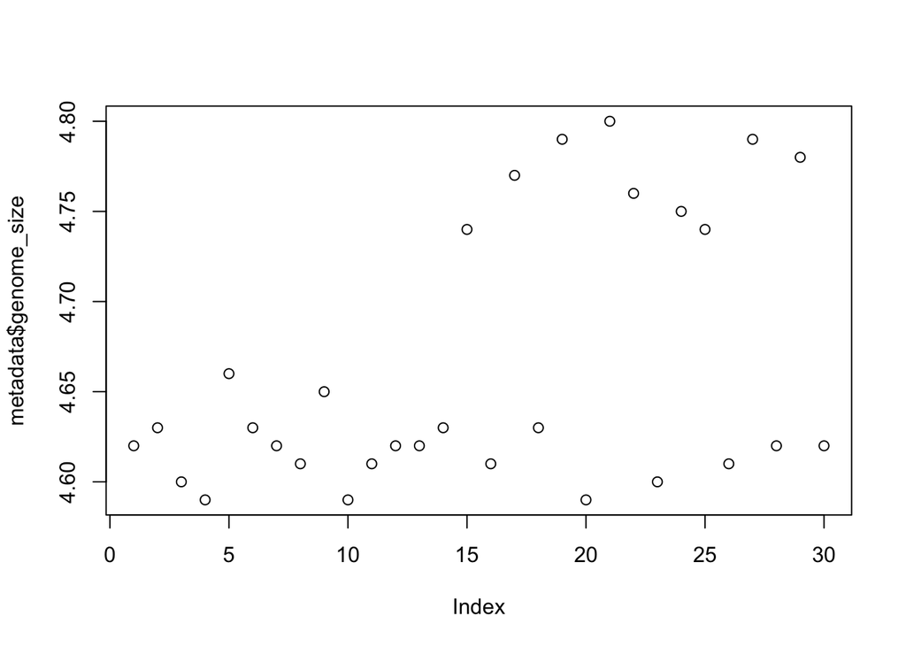

```r
plot(metadata$genome_size)
```

We can change the appearance of the points using the "pch"" argument:

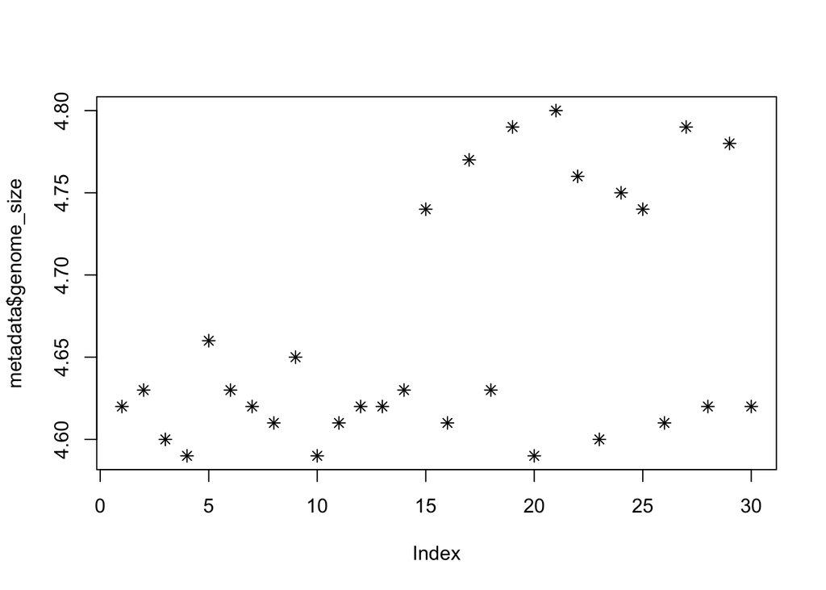

```r
plot(metadata$genome_size, pch=8)
```

We can also include a title using the "main"" argument:

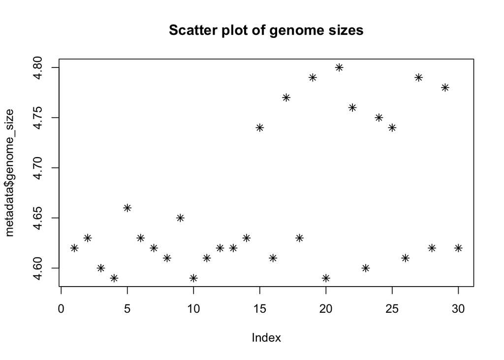

```r
plot(metadata$genome_size, pch=8, main="Scatter plot of genome sizes")
```

### Histogram

If we want to get a frequency distribution of the genome sizes we can use the hist() function:

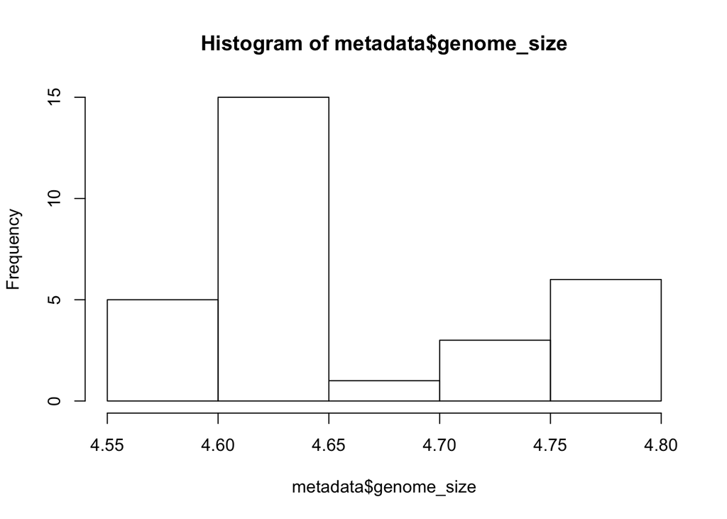

```r
hist(metadata$genome_size)
```

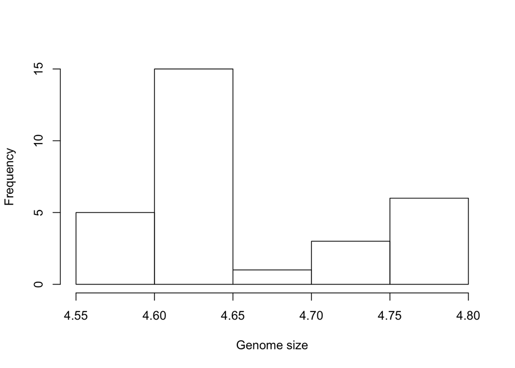

```r
hist(metadata$genome_size, xlab = "Genome size", main = "") #Rename the x-axis, remove title
```

### Boxplot

If we want to show the genome size depending on the citrate metabolism capability we could use the boxplot() function:

boxplot(y~x, data = dataframe_name)

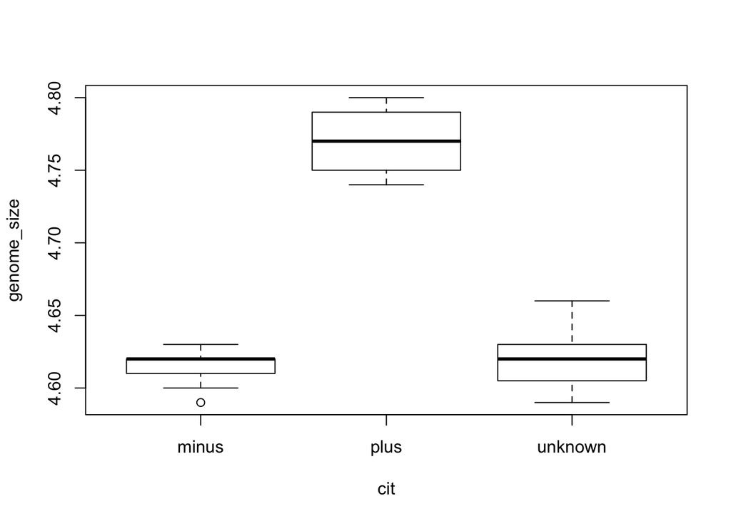

```r
boxplot(genome_size ~ cit, data = metadata)
```

Improve appearance:

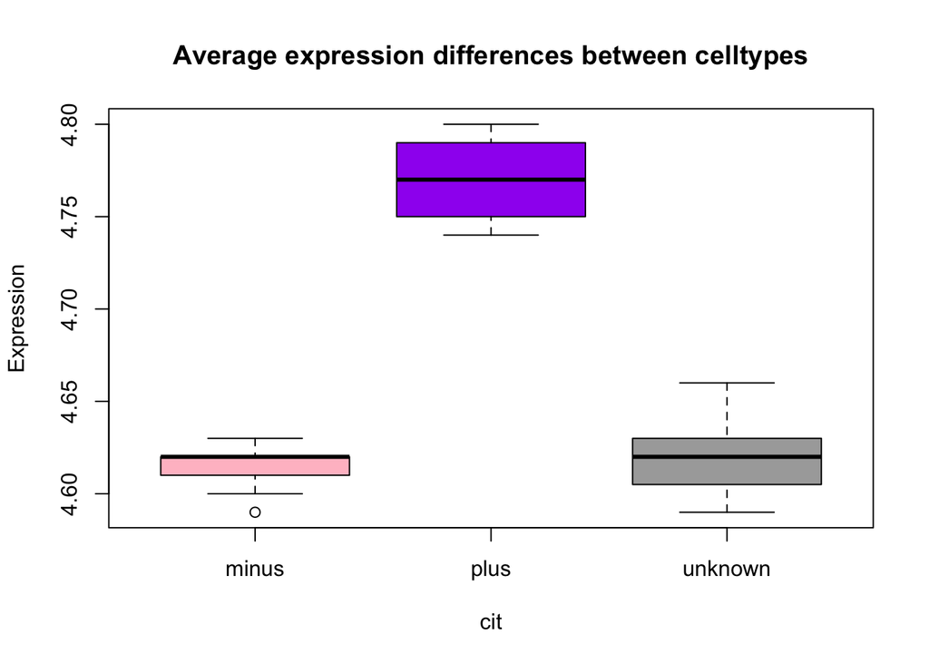

```r
boxplot(genome_size ~ cit, data = metadata,  col=c("pink","purple", "darkgrey"),
        main="Average expression differences between celltypes", ylab="Expression")
```

## Advanced figures (ggplot2)

The package ggplot2() was created to provide functions that help users to create figures in a layered approach with easier manipulation of appearance.

Load ggplot2() package:

```r
library(ggplot2)
```

You will find more information about ggplot2() here: https://ggplot2.tidyverse.org/

Lastly, we need to add information on what data we want to show. This is done in the "aesthetics" = aes():

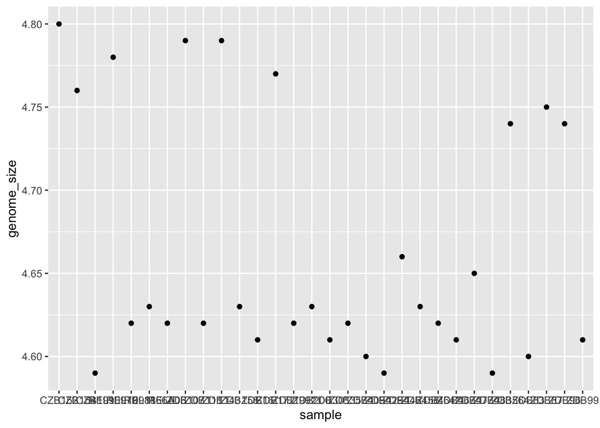

```r
ggplot(metadata) +
  geom_point(aes(x = sample, y= genome_size))
```

Additionally to the x and y coordinates, we can add the following to the aesthetics:

- color (similar to line color)
- fill
- linetype (lty)
- size

First let's modify:

- color so it changes with generation
- shape so it changes with citrate usage status
- size to increase the shape size

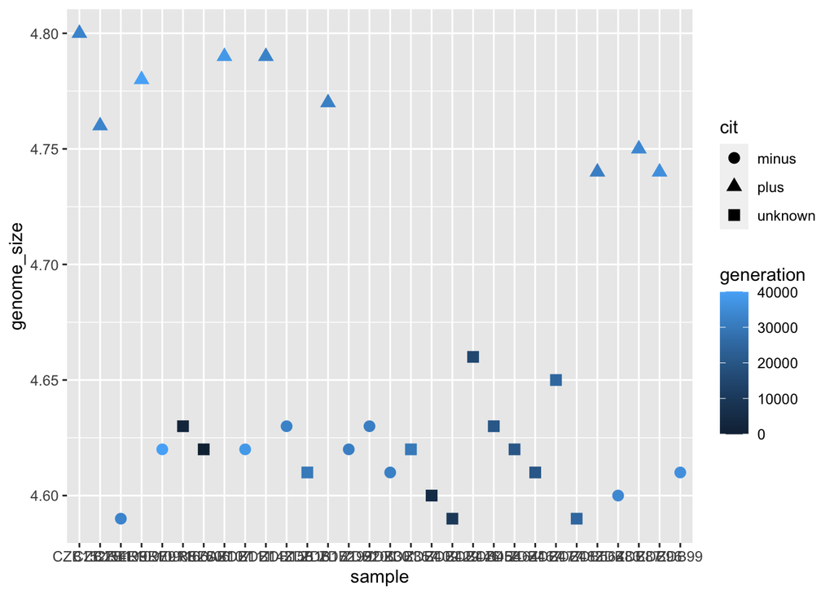

```r
ggplot(metadata) +
  geom_point(aes(x = sample, y= genome_size, color = generation, shape = cit), size = rel(3.0))
```

The lables are hard to read on the x-axis.

We can change the label direction to include another layer called "theme":

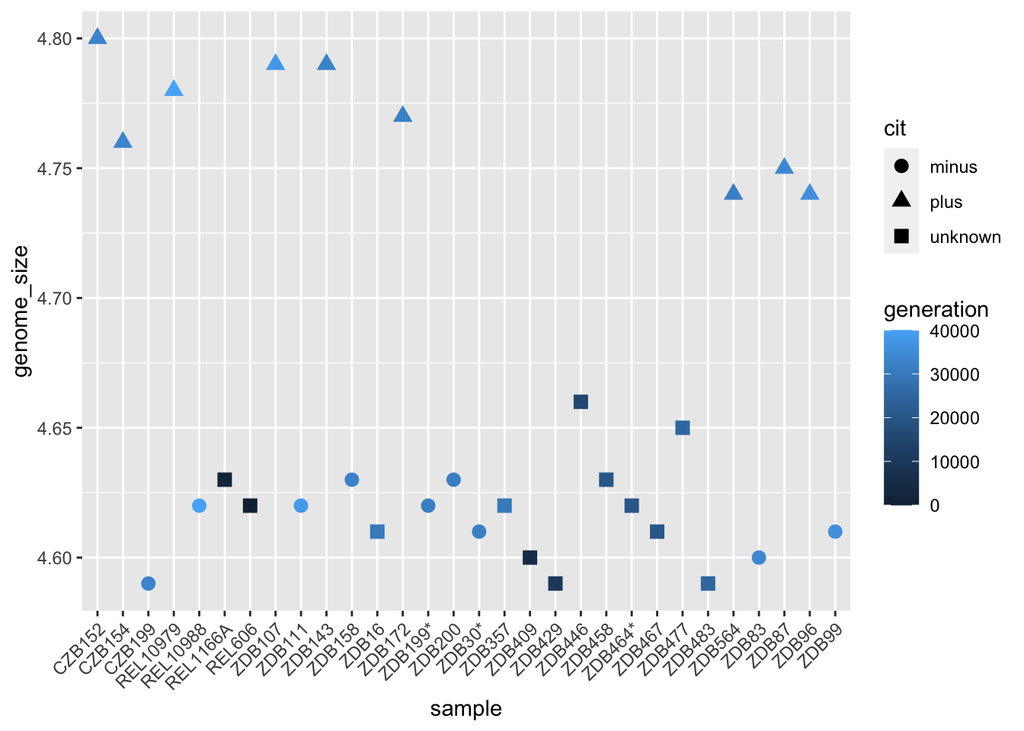

```r
ggplot(metadata) +
  geom_point(aes(x = sample, y= genome_size, color = generation, shape = cit), size = rel(3.0)) +
  theme(axis.text.x = element_text(angle=45, hjust=1))
```

### Histogram:

We can make a histogram by using the function geom_histogram(), instead of geom_point().

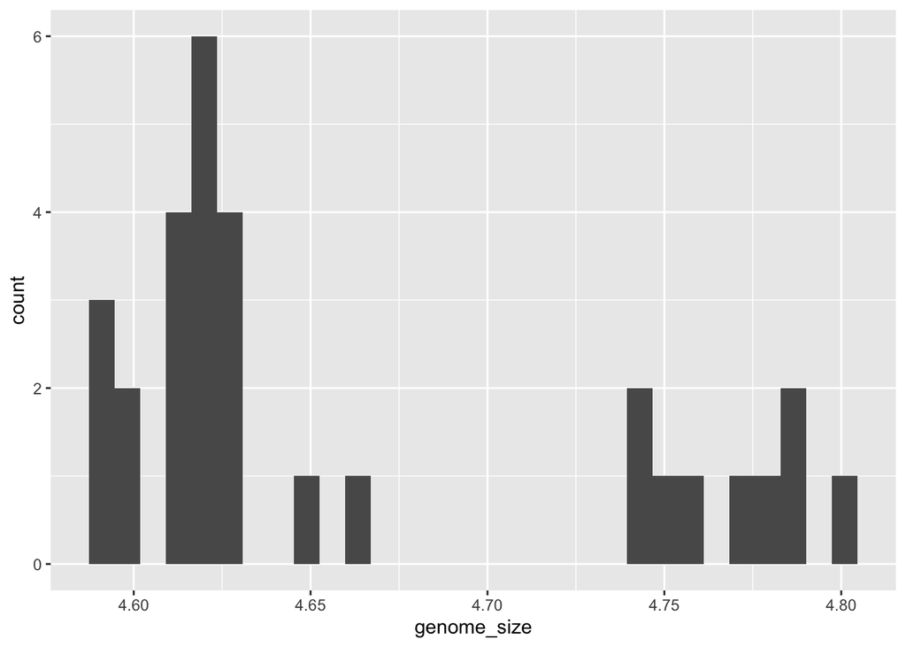

```r
ggplot(metadata) +
  geom_histogram(aes(x = genome_size))
```

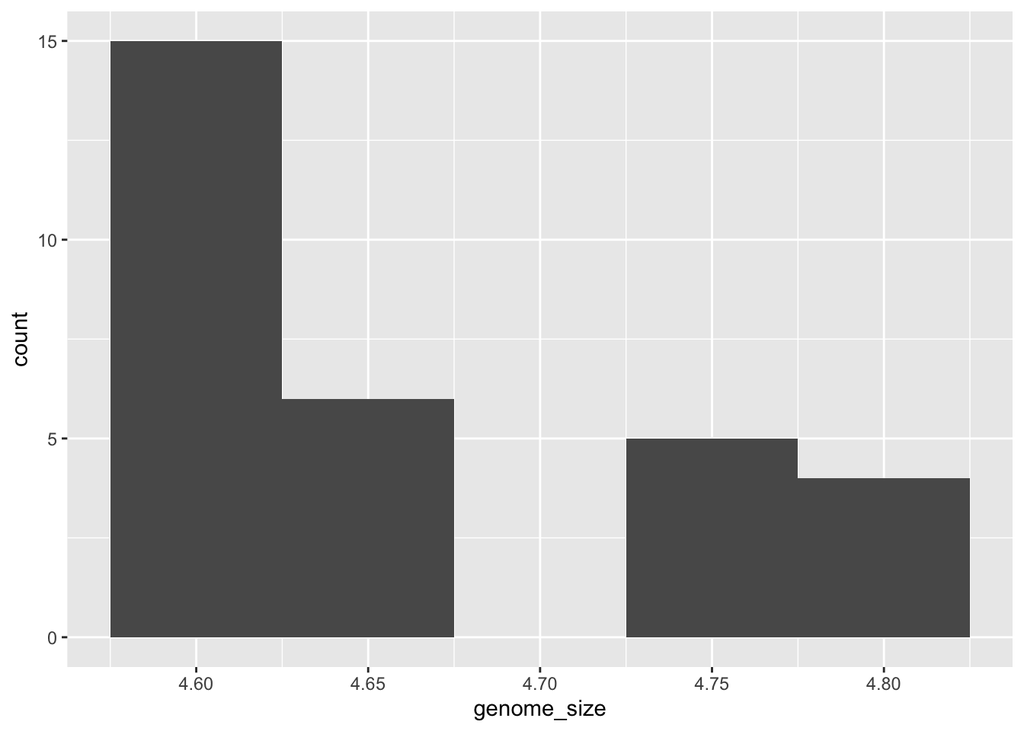

```r
ggplot(metadata) +
  geom_histogram(aes(x = genome_size), binwidth=0.05)
```

### Boxplot:

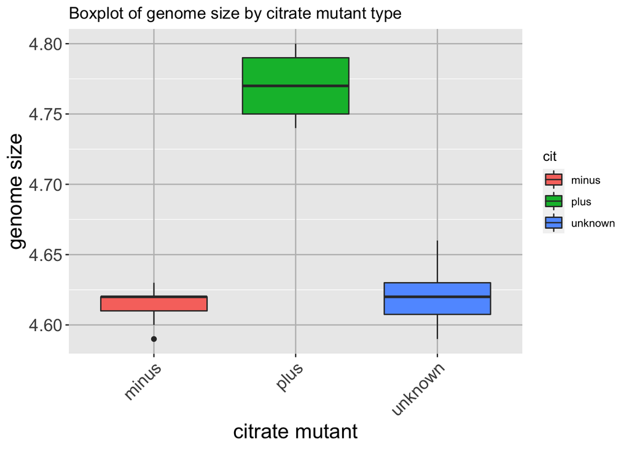

```r
ggplot(metadata) +
  geom_boxplot(aes(x = cit, y = genome_size, fill = cit)) +
  ggtitle('Boxplot of genome size by citrate mutant type') +
  xlab('citrate mutant') +
  ylab('genome size') +
  theme(panel.grid.major = element_line(size = .5, color = "grey"),
          axis.text.x = element_text(angle=45, hjust=1),
          axis.title = element_text(size = rel(1.5)),
          axis.text = element_text(size = rel(1.25)))
```

### Save figure to pdf file

```r
pdf("boxplot.pdf")

ggplot(metadata) +
  geom_boxplot(aes(x = cit, y = genome_size, fill = cit)) +
  ggtitle('Boxplot of genome size by citrate mutant type') +
  xlab('citrate mutant') +
  ylab('genome size') +
  theme(panel.grid.major = element_line(size = .5, color = "grey"),
          axis.text.x = element_text(angle=45, hjust=1),
          axis.title = element_text(size = rel(1.5)),
          axis.text = element_text(size = rel(1.25)))

dev.off()
```